# Summarizing Data: Categorical Data Graphs

## Graphical Summaries

- How to summarize data?
- Depends on data types:
  - Categorical
  - Quantitative

## Graphical Summaries

- How to summarize just categorical data?
- Numerically?
  - Tables (contingency tables)
  - Show frequency of categories
- Graphically?
  - Barplots
  - Piecharts (not recommended)

## Graphical Summaries

**Categorical Data**

- Main plot: bar plot and variations on it
- `barplot()` function in base R can be used
- We'll use `ggplot2` in tidyverse! [cheatsheet](https://www.rstudio.com/wp-content/uploads/2016/11/ggplot2-cheatsheet-2.1.pdf)

## Graphical Summaries

**Categorical Data**

- Main plot: bar plot and variations on it
- `barplot()` function in base R can be used
- We'll use `ggplot2` in tidyverse! [cheatsheet](https://www.rstudio.com/wp-content/uploads/2016/11/ggplot2-cheatsheet-2.1.pdf)
- ggplot2 basics
  - Begin plot with `ggplot(data = ...)`, creates a coordinate system
  - Add "layers" to the system (geoms or stats)
  - Each layer has "mapping" args (aes)

## Graphical Summaries

`ggplot2` needs and syntax

Needs:

- Data Frame
- Aesthetic (aes) - maps variables to properties of geom
  - Ex: size, color, and x, y location(s)
- Geom layer(s) (visualizaton type(s))
- Coordinate system (mostly use Cartesian plane)
- Optional: Titles, etc.

## Graphical Summaries

`ggplot2` needs and syntax

Needs:

- Data Frame
- Aesthetic (aes) - maps variables to properties of geom
- Geom layer(s) (visualizaton type(s))
- Optional: Stat layer, titles, etc.
- Syntax:

```r
g <- ggplot(dataframe, aes(x = , y = , ...)) #Define global properties
g + geom_type(...) + #Can define local aes as well
  geom_type2(...) +
  labs(...)
```

## Graphical Summaries

**Categorical Data**

Example data set about the titanic:

```r
titanicData
```

```
## # A tibble: 1,310 x 14
##   pclass survived name  sex      age sibsp parch ticket  fare cabin
##    <int>    <int> <chr> <chr>  <dbl> <int> <int> <chr>  <dbl> <chr>
## 1      1        1 Alle~ fema~ 29         0     0 24160   211. B5
## 2      1        1 Alli~ male   0.917     1     2 113781  152. C22 ~
## 3      1        0 Alli~ fema~  2         1     2 113781  152. C22 ~
## 4      1        0 Alli~ male  30         1     2 113781  152. C22 ~
## 5      1        0 Alli~ fema~ 25         1     2 113781  152. C22 ~
## # ... with 1,305 more rows, and 4 more variables: embarked <chr>,
## #   boat <chr>, body <int>, home.dest <chr>
```

## Graphical Summaries

**Categorical Data**

- Example bar plot:

```r
ggplot(data = titanicData, aes(x = embarked))
```

## Graphical Summaries

- Notice no plot is made
- Must add geom layer!

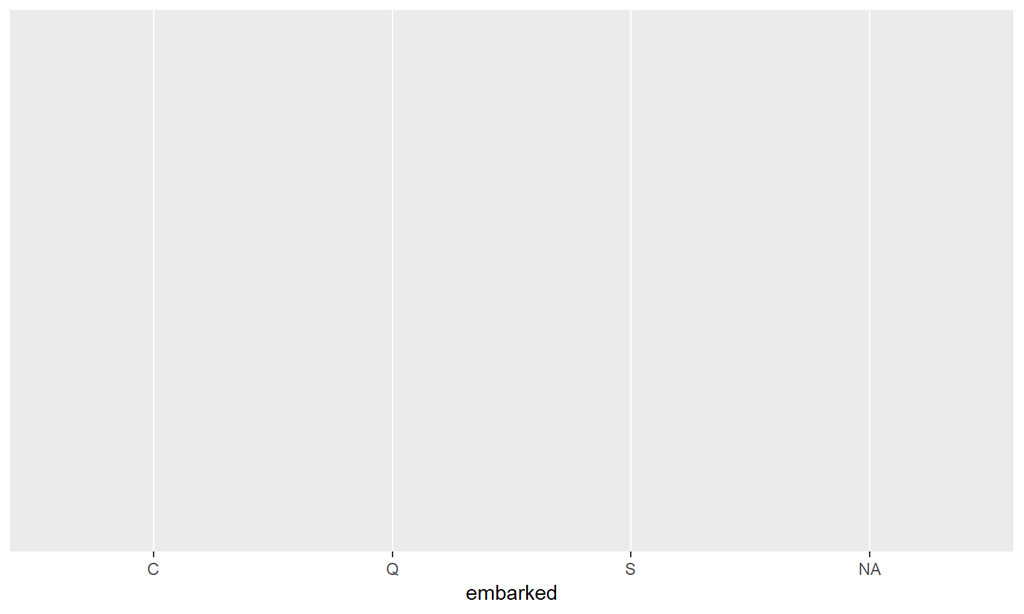

## Graphical Summaries

**Categorical Data**

- Idea: Save base object, then "add layers"

```r
g <- ggplot(data = titanicData, aes(x = embarked))
g + geom_bar()
```

- `aes()` defines visual properties of objects in the plot
  - Commonly `x = , y = , size = , shape = , color = , alpha =`, etc.

## Graphical Summaries

**Categorical Data**

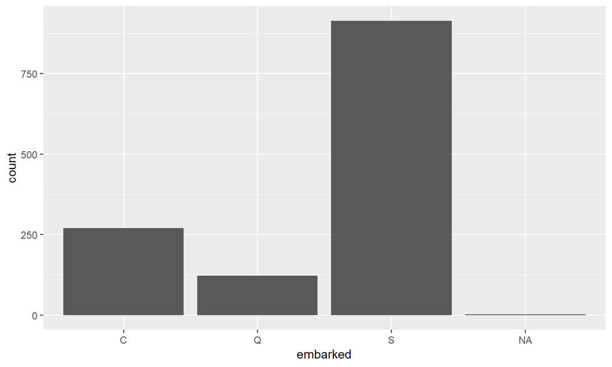

## Graphical Summaries

**Categorical Data**

- How to improve this plot?
- Might remove `NA` category

```r
titanicData <- titanicData %>% drop_na(embarked)
g <- ggplot(data = titanicData, aes(x = embarked))
g + geom_bar()
```

## Graphical Summaries

**Categorical Data**

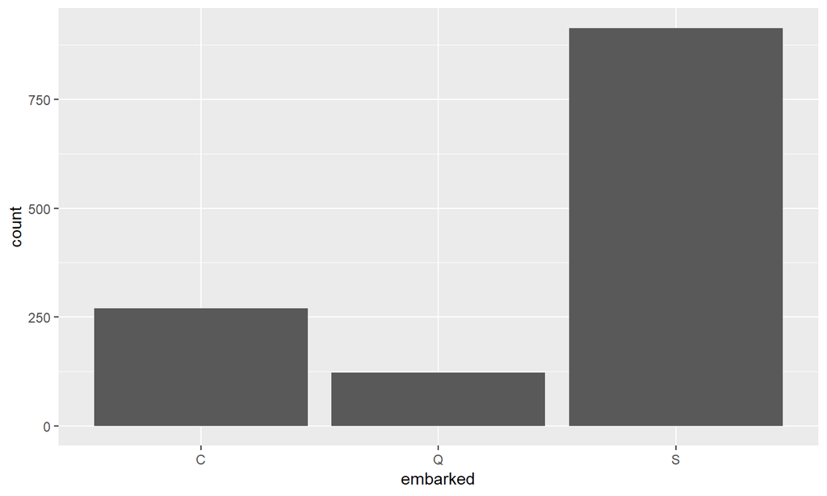

## Graphical Summaries

**Categorical Data**

- How to improve this plot?
- Might add better labels and a title (new layers, see cheat sheet!)

```r
#Fix x axis, x axis label and give title
g + geom_bar() +
  labs(x = "City Embarked", title = "Bar Plot of Embarked City
       for Titanic Passengers") +
  scale_x_discrete(labels = c("Cherbourg","Queenstown","Southampton"))
```

## Graphical Summaries

**Categorical Data**

[figure not shown]

## Graphical Summaries

**Categorical Data**

- Previous plot visualized table for one variable
- How to visualize table for two?
  - Filled bar plot
  - Side-by-side bar plot
- Process the same
  - Create base object
  - Add geoms
  - Use aes to specify aspects of the plot

## Graphical Summaries

**Categorical Data**

- Filled bar plot

```r
g + geom_bar(aes(fill = as.factor(survived)))
```

- ggplot automatically assigns colors etc. and creates legends (except when using `group`)

## Graphical Summaries

**Categorical Data**

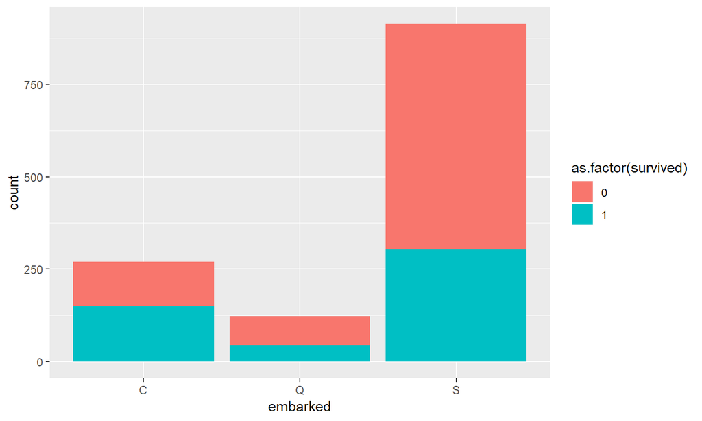

## Graphical Summaries

**Categorical Data**

Add labels and such:

```r
g + geom_bar(aes(fill = as.factor(survived))) +
  labs(x = "City Embarked",
       title = "Bar Plot of Embarked City for Titanic Passengers") +
  scale_x_discrete(labels = c("Cherbourg", "Queenstown", "Southampton")) +
  scale_fill_discrete(name = "Surived", labels = c("No","Yes"))
```

## Graphical Summaries

**Categorical Data**

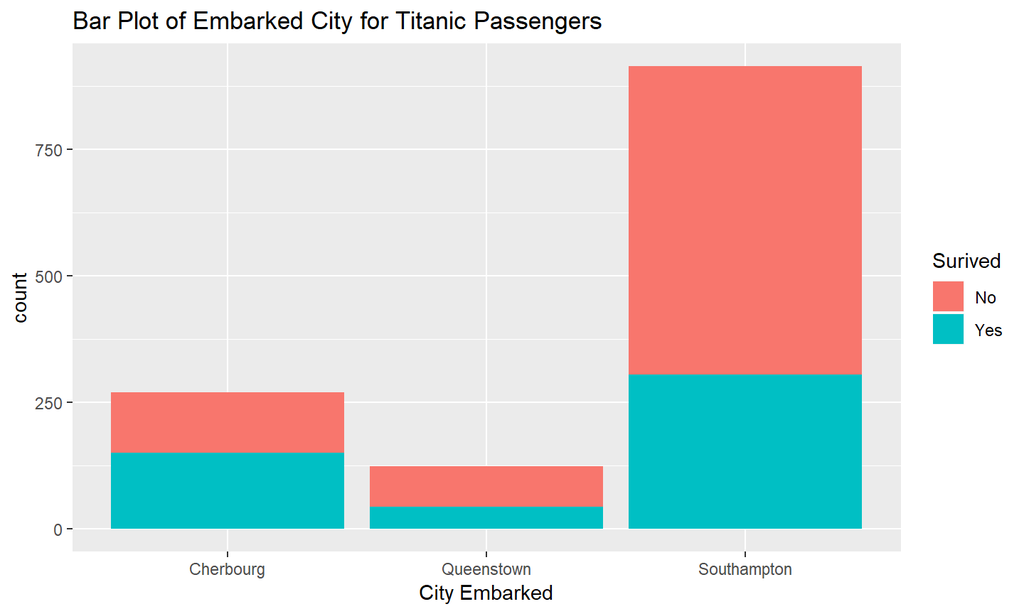

## Graphical Summaries

**Categorical Data**

- Can rotate it

```r
g + geom_bar(aes(fill = as.factor(survived))) +
  labs(x = "City Embarked",
       title = "Bar Plot of Embarked City for Titanic Passengers") +
  scale_x_discrete(labels = c("Cherbourg", "Queenstown", "Southampton")) +
  scale_fill_discrete(name = "Surived",labels = c("No","Yes")) +
  coord_flip()
```

## Graphical Summaries

**Categorical Data**

[figure not shown]

## Graphical Summaries

**Categorical Data**

Note: Most geoms have a corresponding stat that can be used

`geom_bar(mapping = NULL, data = NULL, stat = "count", position = "stack", ..., width = NULL, binwidth = NULL, na.rm = FALSE, show.legend = NA, inherit.aes = TRUE)`

```r
g + geom_bar(aes(fill = as.factor(survived)))
g + stat_count(aes(fill = as.factor(survived))) #equivalent call
```

## Graphical Summaries

**Categorical Data**

Note: Most geoms have a corresponding stat that can be used

Can modify the stat - if you have summary data already, use identity

```r
sumData <- titanicData %>% group_by(embarked, survived) %>% summarize(count = n())
g2 <- ggplot(sumData, aes(x = embarked, y = count))
g2 + geom_bar(aes(fill = as.factor(survived)), stat = "identity")
```

- Would produce same plot we've been making

## Graphical Summaries

**Categorical Data**

- Side-by-side bar plot
- Add position argument (options are `dodge`, `jitter`, `fill`, or `stack`)
  - `dodge` for side-by-side bar plot
  - `jitter` for continuous data with many points at same values
  - `fill` stacks bars and standardises each stack to have constant height
  - `stack` stacks bars on top of each other

```r
g + geom_bar(aes(fill = as.factor(survived)), position = "dodge")
```

## Graphical Summaries

**Categorical Data**

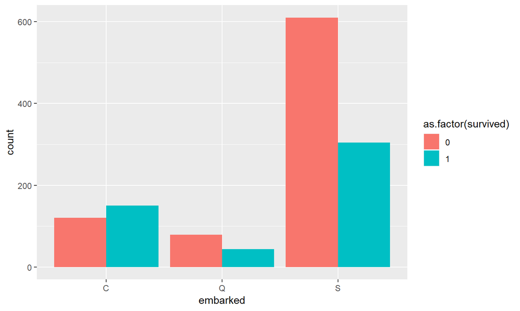

## Graphical Summaries

**Categorical Data**

- `fill` stacks bars and standardises each stack to have constant height

```r
g + geom_bar(aes(fill = as.factor(survived)), position = "fill")
```

## Graphical Summaries

**Categorical Data**

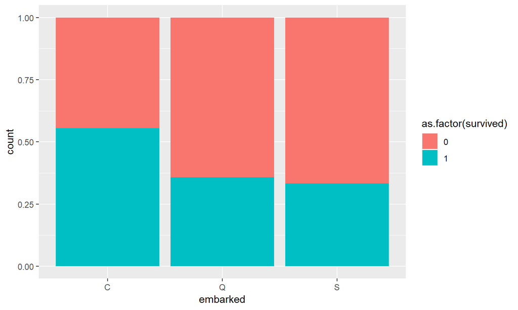

## Graphical Summaries

**Categorical Data**

- How to save tables and graphs?
  - Save tables with write_csv!

```r
tab <- tbl_df(table(titanicData$embarked, titanicData$survived))

names(tab) <- c("Embarked", "Survived", "Count")

write_csv(x = tab, path = "titanicTable.csv", col_names = TRUE)
```

## Graphical Summaries

**Categorical Data**

- How to save tables and graphs?
  - Save graphs with
    - ggsave()
    - 'Export' button

```r
#by default ggsave saves last plot
#guesses file type by extension
ggsave(filename = "output/titanicBarPlot.png")
ggsave(filename = "output/titanicBarPlot.pdf")
```

## Graphical Summaries

**Categorical Data**

- 'Export' button

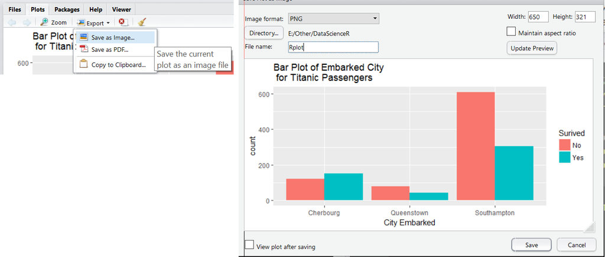

## Recap!

- How to summarize categorical data?
- Numerically?
  - Tables (contingency tables)
    - Show frequency of categories
- Graphically?
  - Barplots
- ggplot (create object, add layers)
  - Data Frame
  - Geoms (Vis type)
  - Aesthetic (aes)
  - Coordinate system, stat, labels, etc.